# DS Capstone Report Milestone #1

Miguel Angel Raviela

8/5/2018

# Overview

This document was created as the first Milestone Report for Capstone Project in the specialization **Data Science by Johns Hopkins University** at Coursera.

In this capstone we will be applying data science in the area of natural language processing, the goal is to create a predictive text model with the provided corpora or also called corpus that can be downloaded from [here](https://d396qusza40orc.cloudfront.net/dsscapstone/dataset/Coursera-SwiftKey.zip)

The corpora are collected from publicly available sources by a web crawler. The crawler checks for language, so as to mainly get texts consisting of the desired language*.

Each entry is tagged with it’s date of publication. Where user comments are included they will be tagged with the date of the main entry.

Each entry is tagged with the type of entry, based on the type of website it is collected from (e.g. newspaper or personal blog) If possible, each entry is tagged with one or more subjects based on the title or keywords of the entry (e.g. if the entry comes from the sports section of a newspaper it will be tagged with “sports” subject).In many cases it’s not feasible to tag the entries (for example, it’s not really practical to tag each individual Twitter entry, though I’ve got some ideas which might be implemented in the future) or no subject is found by the automated process, in which case the entry is tagged with a ‘0’.

# Exploratory Data Analisys

## Understanding Dataset

The data has been download from this link: https://d396qusza40orc.cloudfront.net/dsscapstone/dataset/Coursera-SwiftKey.zip, and uncompressed in ‘data’ folder.

There are 4 languages in this data set.

```r
list.files("data/final")
```

```
## [1] "de_DE" "en_US" "fi_FI" "ru_RU"
```

For this report we will be using only English.

```r
list.files("data/final/en_US")
```

```
## [1] "en_US.blogs.txt"   "en_US.news.txt"    "en_US.twitter.txt"
```

The data in the files was collected from:

- Blogs
- Newspappers
- Twitter

## Exploring the files

Lets load the files to know more about then.

```r
blog.file <- "data/final/en_US/en_US.blogs.txt"
twitter.file <- "data/final/en_US/en_US.twitter.txt"
news.file <- "data/final/en_US/en_US.news.txt"
blogs <- readLines(blog.file, encoding="UTF-8", skipNul = TRUE)
twitter <- readLines(twitter.file, encoding="UTF-8", skipNul = TRUE)
news  <- readLines(news.file, encoding="UTF-8", skipNul = TRUE)
```

## Blog :

- File name: data/final/en_US/en_US.blogs.txt.
- File size: 200.42 MB.
- Lines and chars statistics on the file:

```r
data.frame(t(stri_stats_general(blogs)))
```

```
##    Lines LinesNEmpty     Chars CharsNWhite
## 1 899288      899288 206824382   170389539
```

- Summary of the char quantities per line:

```r
summary(sapply(blogs,FUN=nchar))
```

```
##    Min. 1st Qu.  Median    Mean 3rd Qu.    Max.
##       1      47     156     230     329   40833
```

- Words count summary:

```r
summary(stri_count_words(blogs))
```

```
##    Min. 1st Qu.  Median    Mean 3rd Qu.    Max.
##    0.00    9.00   28.00   41.75   60.00 6726.00
```

## Twitter :

- File name: data/final/en_US/en_US.twitter.txt.
- File size: 159.36 MB.

```r
data.frame(t(stri_stats_general(twitter)))
```

```
##     Lines LinesNEmpty     Chars CharsNWhite
## 1 2360148     2360148 162096241   134082806
```

- Summary of the char quantities per line:

```r
summary(sapply(twitter,FUN=nchar))
```

```
##    Min. 1st Qu.  Median    Mean 3rd Qu.    Max.
##    2.00   37.00   64.00   68.68  100.00  140.00
```

- Words count summary:

```r
summary(stri_count_words(twitter))
```

```
##    Min. 1st Qu.  Median    Mean 3rd Qu.    Max.
##    1.00    7.00   12.00   12.75   18.00   47.00
```

## News :

- File name: data/final/en_US/en_US.news.txt.
- File size: 196.28 MB.

```r
data.frame(t(stri_stats_general(news)))
```

```
##     Lines LinesNEmpty     Chars CharsNWhite
## 1 1010242     1010242 203223154   169860866
```

- Summary of the char quantities per line:

```r
summary(sapply(news,FUN=nchar))
```

```
##    Min. 1st Qu.  Median    Mean 3rd Qu.    Max.
##     1.0   110.0   185.0   201.2   268.0 11384.0
```

- Words count summary:

```r
summary(stri_count_words(news))
```

```
##    Min. 1st Qu.  Median    Mean 3rd Qu.    Max.
##    1.00   19.00   32.00   34.41   46.00 1796.00
```

## Data Preprocessing

These files are big, so our strategy is to work with samples of them.

```r
sample.size <- 100000
```

```r
sample.blogs <- sample(blogs,sample.size)
sample.twitter <- sample(twitter,sample.size)
sample.news <- sample(news,sample.size)
```

- sample.blogs has 11.12% of the original data.
- sample.twitter has 4.24% of the original data.
- sample.news has 9.9% of the original data.

To maintain reproducibility in this research we will save the samples and load it as needed.

```r
save(sample.blogs,sample.twitter,sample.news,file="samples.RData")
```

```r
load("samples.RData")
```

Lets convert the records encoding.

```r
sample.blogs <- iconv(sample.blogs, "latin1", "ASCII", sub="")
sample.twitter <- iconv(sample.twitter, "latin1", "ASCII", sub="")
sample.news <- iconv(sample.news, "latin1", "ASCII", sub="")
```

In order to work with meaningful tokens, we need to remove all punctuation and strange characters, and then lowercase everything and the remove stop words.

A step aditional was added to remove all profanity words using as base next resource https://github.com/shutterstock/List-of-Dirty-Naughty-Obscene-and-Otherwise-Bad-Words/blob/master/en.

```r
profanity.words <- readLines("data/config/en_US/profanity.txt")

corpus.blogs <- Corpus(VectorSource(list(sample.blogs)))
corpus.blogs <- tm_map(corpus.blogs, content_transformer(tolower))
corpus.blogs <- tm_map(corpus.blogs, content_transformer(removePunctuation))
corpus.blogs <- tm_map(corpus.blogs, content_transformer(removeNumbers))
corpus.blogs <- tm_map(corpus.blogs, removeWords, stopwords("english"))
corpus.blogs <- tm_map(corpus.blogs, removeWords, profanity.words)
corpus.blogs <- tm_map(corpus.blogs, stripWhitespace)

corpus.blogs <- tm_map(corpus.blogs, stemDocument, language='english')
```

```r
corpus.twitter <- Corpus(VectorSource(list(sample.twitter)))
corpus.twitter <- tm_map(corpus.twitter, content_transformer(tolower))
corpus.twitter <- tm_map(corpus.twitter, content_transformer(removePunctuation))
corpus.twitter <- tm_map(corpus.twitter, content_transformer(removeNumbers))
corpus.twitter <- tm_map(corpus.twitter, removeWords, stopwords("english"))
corpus.twitter <- tm_map(corpus.twitter, removeWords, profanity.words)
corpus.twitter <- tm_map(corpus.twitter, stripWhitespace)

corpus.twitter <- tm_map(corpus.twitter, stemDocument, language='english')
```

```r
corpus.news <- Corpus(VectorSource(list(sample.news)))
corpus.news <- tm_map(corpus.news, content_transformer(tolower))
corpus.news <- tm_map(corpus.news, content_transformer(removePunctuation))
corpus.news <- tm_map(corpus.news, content_transformer(removeNumbers))
corpus.news <- tm_map(corpus.news, removeWords, stopwords("english"))
corpus.news <- tm_map(corpus.news, removeWords, profanity.words)
corpus.news <- tm_map(corpus.news, stripWhitespace)

corpus.news <- tm_map(corpus.news, stemDocument, language='english')
```

The data is prepared to be analized.

## Analysis

Now we can start doing analysis based on [N-Grams](http://en.wikipedia.org/wiki/N-gram).

### Unigrams

#### Blogs

Top ten:

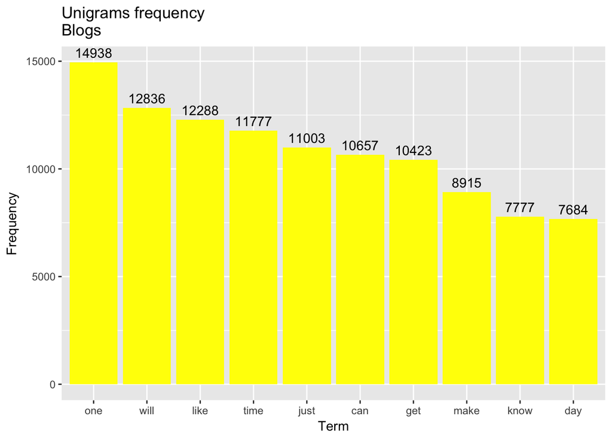

```r
UnigramTokenizer <- function(x) NGramTokenizer(x, Weka_control(min = 1, max = 1)) #Define the unigram function
unigram.termdocmatrix.blogs <- TermDocumentMatrix(corpus.blogs, control = list(tokenize = UnigramTokenizer)) #generate unigrams

unigram.df.blogs <- data.frame(Term = unigram.termdocmatrix.blogs$dimnames$Terms,
                                 Freq = unigram.termdocmatrix.blogs$v) #transform into dataframe
unigram.df.blogs <- unigram.df.blogs[order(unigram.df.blogs$Freq,decreasing = T),] # reorder dataframe

ggplot(head(unigram.df.blogs,10), aes(x=reorder(Term,-Freq), y=Freq)) +
  geom_bar(stat="Identity", fill="yellow") +
  geom_text(aes(label=Freq), vjust = -0.5) +
  ggtitle("Unigrams frequency\nBlogs") +
  ylab("Frequency") +
  xlab("Term")
```

- Whe have 80092 unique words on this sample.
- 45363 words occurs only one time.

How many words are needed to cover 50% of the instances?

```r
cumsum.blogs <- cumsum(unigram.df.blogs$Freq)
limit.50.blogs <- sum(unigram.df.blogs$Freq)*0.5

length((cumsum.blogs[cumsum.blogs <=  limit.50.blogs]))
```

```
## [1] 549
```

How many words are needed to cover 90% of the instances?

```r
limit.90.blogs <- sum(unigram.df.blogs$Freq)*0.9

length((cumsum.blogs[cumsum.blogs <=  limit.90.blogs]))
```

```
## [1] 6732
```

#### Twitter

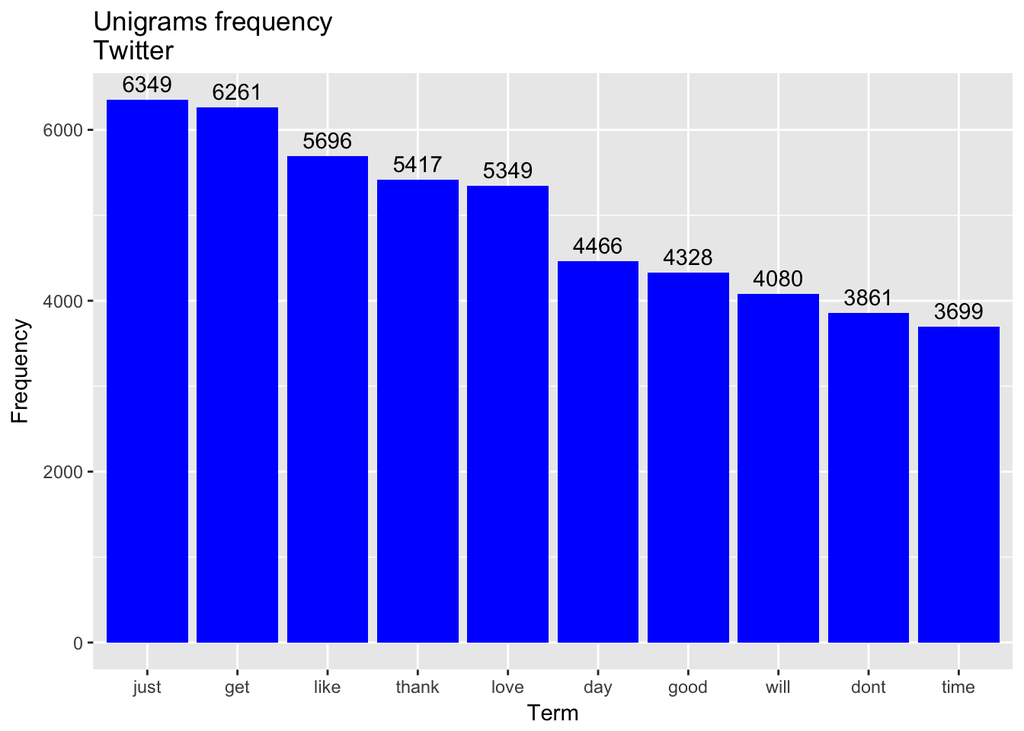

```r
unigram.termdocmatrix.twitter <- TermDocumentMatrix(corpus.twitter, control = list(tokenize = UnigramTokenizer)) #generate unigrams

unigram.df.twitter <- data.frame(Term = unigram.termdocmatrix.twitter$dimnames$Terms,
                                 Freq = unigram.termdocmatrix.twitter$v) #transform into dataframe
unigram.df.twitter <- unigram.df.twitter[order(unigram.df.twitter$Freq,decreasing = T),] # reorder dataframe

ggplot(head(unigram.df.twitter,10), aes(x=reorder(Term,-Freq), y=Freq)) +
  geom_bar(stat="Identity", fill="blue") +
  geom_text(aes(label=Freq), vjust = -0.5) +
  ggtitle("Unigrams frequency\nTwitter") +
  ylab("Frequency") +
  xlab("Term")
```

- Whe have 49386 unique words on this sample.
- 31566 words occurs only one time.

How many words are needed to cover 50% of the instances?

```r
cumsum.twitter <- cumsum(unigram.df.twitter$Freq)
limit.50.twitter <- sum(unigram.df.twitter$Freq)*0.5

length((cumsum.twitter[cumsum.twitter <=  limit.50.twitter]))
```

```
## [1] 350
```

How many words are needed to cover 90% of the instances?

```r
limit.90.twitter <- sum(unigram.df.twitter$Freq)*0.9

length((cumsum.twitter[cumsum.twitter <=  limit.90.twitter]))
```

```
## [1] 6379
```

#### News

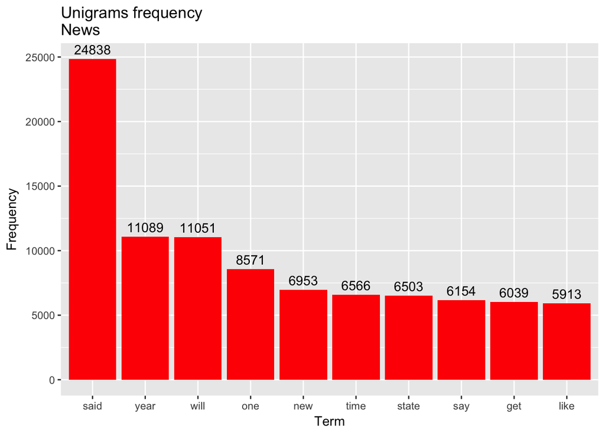

```r
unigram.termdocmatrix.news <- TermDocumentMatrix(corpus.news, control = list(tokenize = UnigramTokenizer)) #generate unigrams

unigram.df.news <- data.frame(Term = unigram.termdocmatrix.news$dimnames$Terms,
                                 Freq = unigram.termdocmatrix.news$v) #transform into dataframe
unigram.df.news <- unigram.df.news[order(unigram.df.news$Freq,decreasing = T),] # reorder dataframe

ggplot(head(unigram.df.news,10), aes(x=reorder(Term,-Freq), y=Freq)) +
  geom_bar(stat="Identity", fill="red") +
  geom_text(aes(label=Freq), vjust = -0.5) +
  ggtitle("Unigrams frequency\nNews") +
  ylab("Frequency") +
  xlab("Term")
```

- Whe have 72643 unique words on this sample.
- 36539 words occurs only one time.

How many words are needed to cover 50% of the instances?

```r
cumsum.news <- cumsum(unigram.df.news$Freq)
limit.50.news <- sum(unigram.df.news$Freq)*0.5

length((cumsum.news[cumsum.news <=  limit.50.news]))
```

```
## [1] 662
```

How many words are needed to cover 90% of the instances?

```r
limit.90.news <- sum(unigram.df.news$Freq)*0.9

length((cumsum.news[cumsum.news <=  limit.90.news]))
```

```
## [1] 7495
```

### Bigrams

#### Blogs

Top ten:

[figure not shown]

```r
BigramTokenizer <- function(x) NGramTokenizer(x, Weka_control(min = 2, max = 2)) #Define the bigram function
bigram.termdocmatrix.blogs <- TermDocumentMatrix(corpus.blogs, control = list(tokenize = BigramTokenizer)) #generate bigrams

bigram.df.blogs <- data.frame(Term = bigram.termdocmatrix.blogs$dimnames$Terms,
                                 Freq = bigram.termdocmatrix.blogs$v) #transform into dataframe
bigram.df.blogs <- bigram.df.blogs[order(bigram.df.blogs$Freq,decreasing = T),] # reorder dataframe

ggplot(head(bigram.df.blogs,10), aes(x=reorder(Term,-Freq), y=Freq)) +
  geom_bar(stat="Identity", fill="yellow") +
  geom_text(aes(label=Freq), vjust = -0.5) +
  ggtitle("Bigrams frequency\nBlogs") +
  ylab("Frequency") +
  xlab("Term")
```

How many bigrams are needed to cover 50% of the instances?

```r
cumsum.blogs <- cumsum(bigram.df.blogs$Freq)
limit.50.blogs <- sum(bigram.df.blogs$Freq)*0.5

length((cumsum.blogs[cumsum.blogs <=  limit.50.blogs]))
```

[output not shown]

How many bigrams are needed to cover 90% of the instances?

```r
limit.90.blogs <- sum(bigram.df.blogs$Freq)*0.9

length((cumsum.blogs[cumsum.blogs <=  limit.90.blogs]))
```

[output not shown]

#### Twitter

[figure not shown]

```r
bigram.termdocmatrix.twitter <- TermDocumentMatrix(corpus.twitter, control = list(tokenize = BigramTokenizer)) #generate bigrams

bigram.df.twitter <- data.frame(Term = bigram.termdocmatrix.twitter$dimnames$Terms,
                                 Freq = bigram.termdocmatrix.twitter$v) #transform into dataframe
bigram.df.twitter <- bigram.df.twitter[order(bigram.df.twitter$Freq,decreasing = T),] # reorder dataframe

ggplot(head(bigram.df.twitter,10), aes(x=reorder(Term,-Freq), y=Freq)) +
  geom_bar(stat="Identity", fill="blue") +
  geom_text(aes(label=Freq), vjust = -0.5) +
  ggtitle("Bigrams frequency\nTwitter") +
  ylab("Frequency") +
  xlab("Term")
```

How many bigrams are needed to cover 50% of the instances?

```r
cumsum.twitter <- cumsum(bigram.df.twitter$Freq)
limit.50.twitter <- sum(bigram.df.twitter$Freq)*0.5

length((cumsum.twitter[cumsum.twitter <=  limit.50.twitter]))
```

[output not shown]

How many bigrams are needed to cover 90% of the instances?

```r
limit.90.twitter <- sum(bigram.df.twitter$Freq)*0.9

length((cumsum.twitter[cumsum.twitter <=  limit.90.twitter]))
```

[output not shown]

#### News

[figure not shown]

```r
bigram.termdocmatrix.news <- TermDocumentMatrix(corpus.news, control = list(tokenize = BigramTokenizer)) #generate bigrams

bigram.df.news <- data.frame(Term = bigram.termdocmatrix.news$dimnames$Terms,
                                 Freq = bigram.termdocmatrix.news$v) #transform into dataframe
bigram.df.news <- bigram.df.news[order(bigram.df.news$Freq,decreasing = T),] # reorder dataframe

ggplot(head(bigram.df.news,10), aes(x=reorder(Term,-Freq), y=Freq)) +
  geom_bar(stat="Identity", fill="red") +
  geom_text(aes(label=Freq), vjust = -0.5) +
  ggtitle("Bigrams frequency\nNews") +
  ylab("Frequency") +
  xlab("Term")
```

How many bigrams are needed to cover 50% of the instances?

```r
cumsum.news <- cumsum(bigram.df.news$Freq)
limit.50.news <- sum(bigram.df.news$Freq)*0.5

length((cumsum.news[cumsum.news <=  limit.50.news]))
```

[output not shown]

How many bigrams are needed to cover 90% of the instances?

```r
limit.90.news <- sum(bigram.df.news$Freq)*0.9

length((cumsum.news[cumsum.news <=  limit.90.news]))
```

[output not shown]